# Analyzing Individual BGG Users

Phil Henrickson

2021-12-31

# **GOBbluth89’s** BoardGameGeek Collection

This notebook contains a set of analyses for the selected user’s boardgamegeek collection. The bulk of the analysis is focused on building a user-specific predictive model to predict the games that GOBbluth89 is likely to own. This enables to ask questions like, based on the games the user currently owns, what games are a good fit for their collection? What upcoming games are they likely to purchase?

This analysis is based on data from BoardGameGeek that was last updated on **2021-12-20.**

# 1 Collection Overview

We can look at a basic description of the number of games that the user owns, has rated, has previously owned, etc.

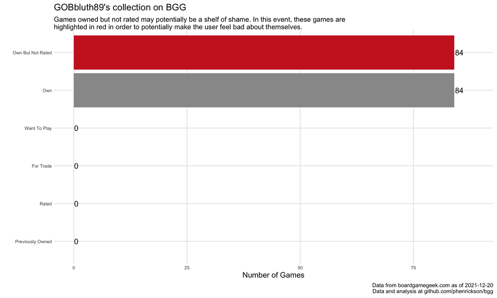

What years has the user owned/rated games from? While we can’t see when a user added or removed a game from their collection, we can look at their collection by the years in which their games were published.

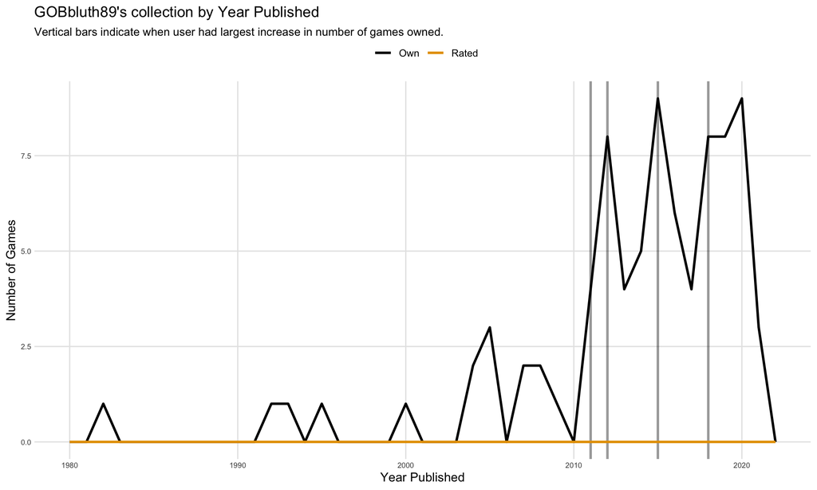

## 1.1 What types of games does GOBbluth89 own?

We can look at the most frequent types of categories, mechanics, designers, and artists that appear in a user’s collection.

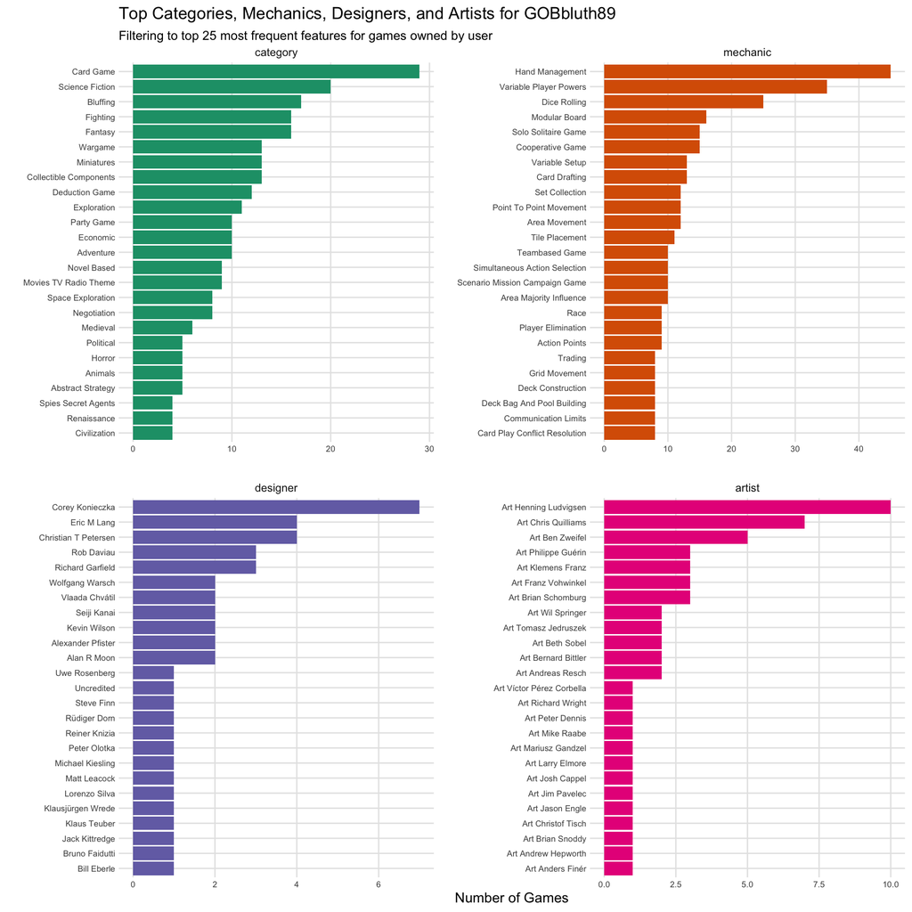

# 2 Modeling **GOBbluth89’s** Collection

| username | dataset | period | games_owned | games_rated | games_played |
| --- | --- | --- | --- | --- | --- |
| GOBbluth89 | training | published before 2020 | 59 | 0 | 59 |
| GOBbluth89 | test | published 2020 or later | 12 | 0 | 12 |

There are two main (binary) outcomes we will be modeling for the user.

The first, **own** refers to whether the user currently lists a game as owned in their collection. The second, **played** refers to whether the user currently owns, has rated, or previously owned a game. This means the latter will generally have a larger list of games, but may still be a useful category to examine for people who play lots of games without necessarily owning them.

We will train predictive models to learn the probability that the user will own or play individual games based on their features.

## 2.1 Coefficients for GOBbluth89

We can examine coefficients from the trained modes, which are penalized logistic regressions fit to our two main outcomes. Positive values indicate that a feature increases a user’s probabilility of owning/rating a game, while negative values indicate a feature decreases the probability.

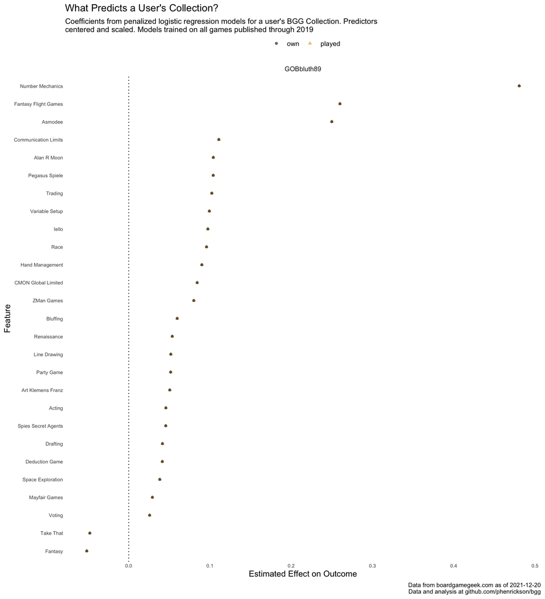

## 2.2 Visualizing Predictors for GOBbluth89’s Collection

Why did the model identify these features? We can make density plots of the important features for predicting whether the user owned a game. Blue indicates the density for games owned by the user, while grey indicates the density for games not owned by the user.

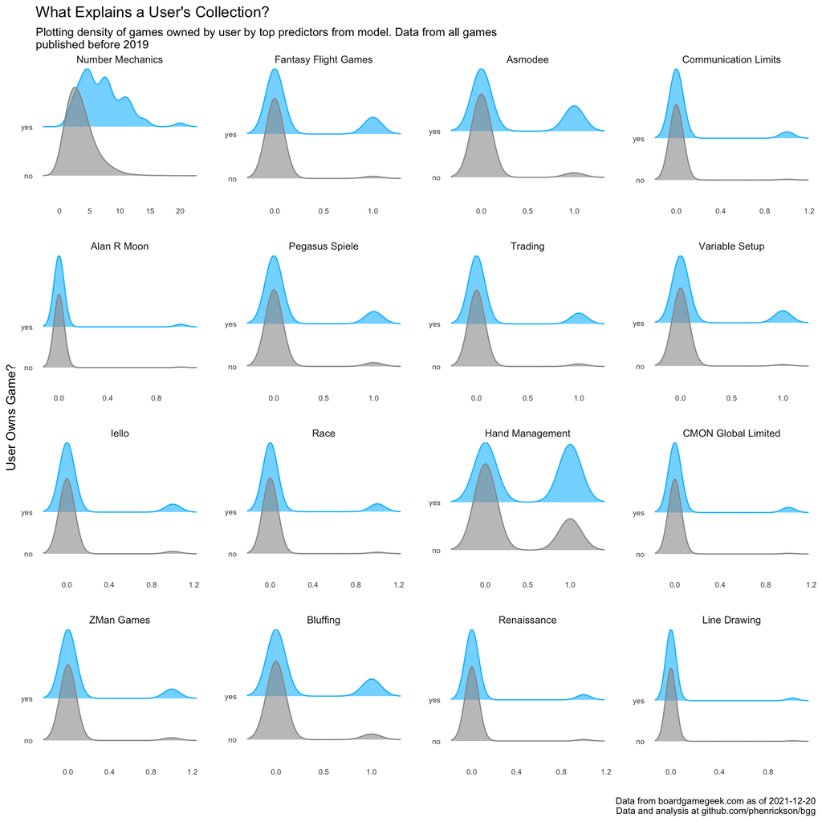

Binary predictors can be difficult to see with this visualization, so we can also directly examine the percentage of games in a user’s collection with a predictor vs the percentage of all games with that predictor.

| username | Feature | % of Games with Feature In_Collection | % of Games with Feature All_Games | Ratio |
| --- | --- | --- | --- | --- |
| GOBbluth89 | Communication Limits | 8.5% | 0.9% | 8.9 |
| GOBbluth89 | CMON Global Limited | 6.8% | 0.8% | 8.6 |
| GOBbluth89 | Variable Setup | 15.3% | 1.8% | 8.5 |
| GOBbluth89 | Fantasy Flight Games | 20.3% | 2.5% | 8.1 |
| GOBbluth89 | End Game Bonuses | 8.5% | 1.2% | 6.8 |
| GOBbluth89 | Drafting | 6.8% | 1.0% | 6.7 |
| GOBbluth89 | Space Exploration | 10.2% | 1.6% | 6.3 |
| GOBbluth89 | Race | 10.2% | 1.8% | 5.6 |
| GOBbluth89 | Asmodee | 28.8% | 5.2% | 5.5 |
| GOBbluth89 | Spies Secret Agents | 6.8% | 1.3% | 5.3 |
| GOBbluth89 | Acting | 5.1% | 1.1% | 4.8 |
| GOBbluth89 | Line Drawing | 3.4% | 0.7% | 4.7 |
| GOBbluth89 | Trading | 13.6% | 3.1% | 4.3 |
| GOBbluth89 | Voting | 10.2% | 2.4% | 4.3 |
| GOBbluth89 | ZMan Games | 11.9% | 3.5% | 3.4 |
| GOBbluth89 | Renaissance | 6.8% | 2.0% | 3.4 |
| GOBbluth89 | Iello | 10.2% | 3.1% | 3.3 |
| GOBbluth89 | Pegasus Spiele | 15.3% | 4.7% | 3.2 |
| GOBbluth89 | Bluffing | 20.3% | 6.7% | 3.1 |
| GOBbluth89 | Mayfair Games | 6.8% | 2.4% | 2.9 |
| GOBbluth89 | Deduction Game | 16.9% | 6.3% | 2.7 |
| GOBbluth89 | Party Game | 16.9% | 8.4% | 2.0 |
| GOBbluth89 | Hand Management | 49.2% | 26.6% | 1.8 |
| GOBbluth89 | Fantasy | 10.2% | 14.9% | 0.7 |
| GOBbluth89 | Take That | 3.4% | 6.7% | 0.5 |

# 3 Assess Model’s Performance on Training Set

Before predicting games in upcoming years, we can examine how well the model did and what games it liked in the training set. In this case, we used resampling techniques (cross validation) to ensure that the model had not seen a game before making its predictions.

## 3.1 Separation Plot

An easy way to examine the performance of classification model is to view a separation plot. We plot the predicted probabilities from the model for every game (from resampling) from lowest to highest. We then overlay a blue line for any game that the user does own. A good classifier is one that is able to *separate* the blue (games owned by the user) from the white (games not owned by the user), with most of the blue occurring at the highest probabilities (right side of the chart).

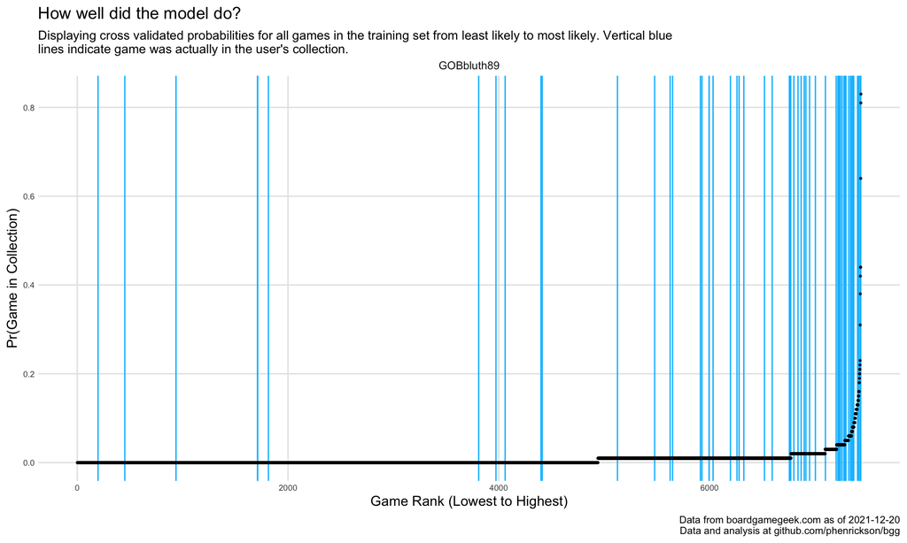

## 3.2 Top Games for **GOBbluth89** from Training Set

We can display this information in table form, displaying the 100 games with the highest probability of ownership, adding a blue line when the user does own the game.

| username | yearpublished | game_id | name | pred_played | pred_own | actual_played | actual_own |
| --- | --- | --- | --- | --- | --- | --- | --- |
| GOBbluth89 | 2018 | 205896 | Rising Sun | 0.83 | 0.83 | 0 | 0 |
| GOBbluth89 | 2008 | 37111 | Battlestar Galactica: The Board Game | 0.81 | 0.81 | 0 | 0 |
| GOBbluth89 | 2017 | 233078 | Twilight Imperium: Fourth Edition | 0.64 | 0.64 | 1 | 1 |
| GOBbluth89 | 2010 | 25292 | Merchants & Marauders | 0.44 | 0.44 | 0 | 0 |
| GOBbluth89 | 2017 | 174430 | Gloomhaven | 0.44 | 0.44 | 1 | 1 |
| GOBbluth89 | 2018 | 244711 | Newton | 0.42 | 0.42 | 0 | 0 |
| GOBbluth89 | 2000 | 478 | Citadels | 0.38 | 0.38 | 0 | 0 |
| GOBbluth89 | 2010 | 73171 | Earth Reborn | 0.31 | 0.31 | 0 | 0 |
| GOBbluth89 | 2008 | 39463 | Cosmic Encounter | 0.23 | 0.23 | 1 | 1 |
| GOBbluth89 | 2011 | 59959 | Letters from Whitechapel | 0.22 | 0.22 | 0 | 0 |
| GOBbluth89 | 2016 | 198773 | Codenames: Pictures | 0.21 | 0.21 | 0 | 0 |
| GOBbluth89 | 2010 | 68182 | Isla Dorada | 0.21 | 0.21 | 0 | 0 |
| GOBbluth89 | 2017 | 232918 | Fallout | 0.20 | 0.20 | 0 | 0 |
| GOBbluth89 | 2019 | 280136 | Paranormal Detectives | 0.20 | 0.20 | 0 | 0 |
| GOBbluth89 | 2005 | 18723 | Aye, Dark Overlord! The Red Box | 0.19 | 0.19 | 0 | 0 |
| GOBbluth89 | 2018 | 225694 | Decrypto | 0.18 | 0.18 | 0 | 0 |
| GOBbluth89 | 2019 | 269385 | The Lord of the Rings: Journeys in Middle-Earth | 0.18 | 0.18 | 0 | 0 |
| GOBbluth89 | 1997 | 42 | Tigris & Euphrates | 0.16 | 0.16 | 0 | 0 |
| GOBbluth89 | 2016 | 200680 | Agricola (Revised Edition) | 0.16 | 0.16 | 0 | 0 |
| GOBbluth89 | 2013 | 144239 | Impulse | 0.16 | 0.16 | 0 | 0 |
| GOBbluth89 | 2010 | 65200 | Asteroyds | 0.16 | 0.16 | 0 | 0 |
| GOBbluth89 | 2015 | 170216 | Blood Rage | 0.15 | 0.15 | 0 | 0 |
| GOBbluth89 | 2018 | 231327 | The Grizzled: Armistice Edition | 0.15 | 0.15 | 0 | 0 |
| GOBbluth89 | 2005 | 12493 | Twilight Imperium: Third Edition | 0.15 | 0.15 | 1 | 1 |
| GOBbluth89 | 2009 | 45134 | Arcana | 0.14 | 0.14 | 0 | 0 |
| GOBbluth89 | 2018 | 257499 | Arkham Horror (Third Edition) | 0.14 | 0.14 | 0 | 0 |
| GOBbluth89 | 2011 | 102548 | Dungeon Fighter | 0.14 | 0.14 | 0 | 0 |
| GOBbluth89 | 2003 | 6472 | A Game of Thrones | 0.14 | 0.14 | 0 | 0 |
| GOBbluth89 | 2019 | 283863 | The Magnificent | 0.13 | 0.13 | 0 | 0 |
| GOBbluth89 | 2012 | 104710 | Wiz-War (Eighth Edition) | 0.13 | 0.13 | 0 | 0 |

[output cut: 70 more lines]

We can also more formally assess how well the model did in resampling by looking at the area under the receiver operating characteristic. A perfect model would receive a score of 1, while a model that cannot predict the outcome will default to a score of 0.5. The extent to which something is a *good* score depends on the setting, but generally anything in the .8 to .9 range is very good while the .7 to .8 range is perfectly acceptable.

| username | outcome_type | .metric | .estimator | .estimate |
| --- | --- | --- | --- | --- |
| GOBbluth89 | own | roc_auc | binary | 0.835 |
| GOBbluth89 | played | roc_auc | binary | 0.835 |

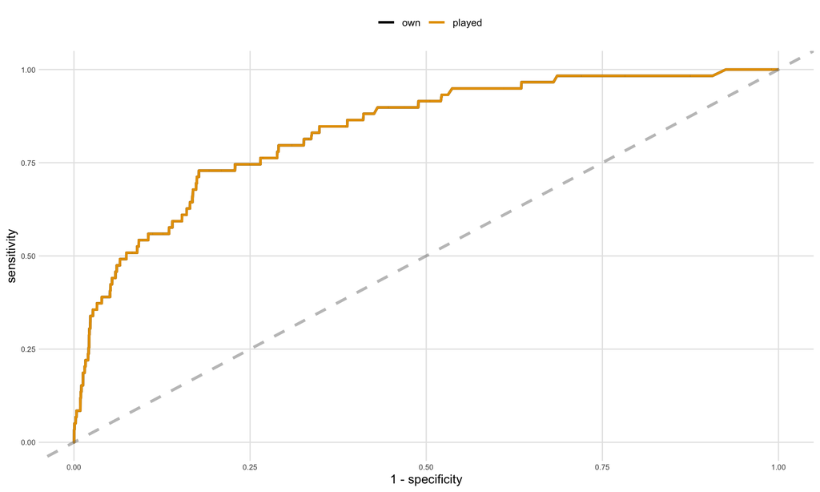

Another way to think about the model performance is to view its lift, or its ability to detect the positive outcomes over that of a null model. High lift indicates the model can much more quickly find all of the positive outcomes (in this case, games owned or played by the user), while a model with no lift is no better than random guessing.

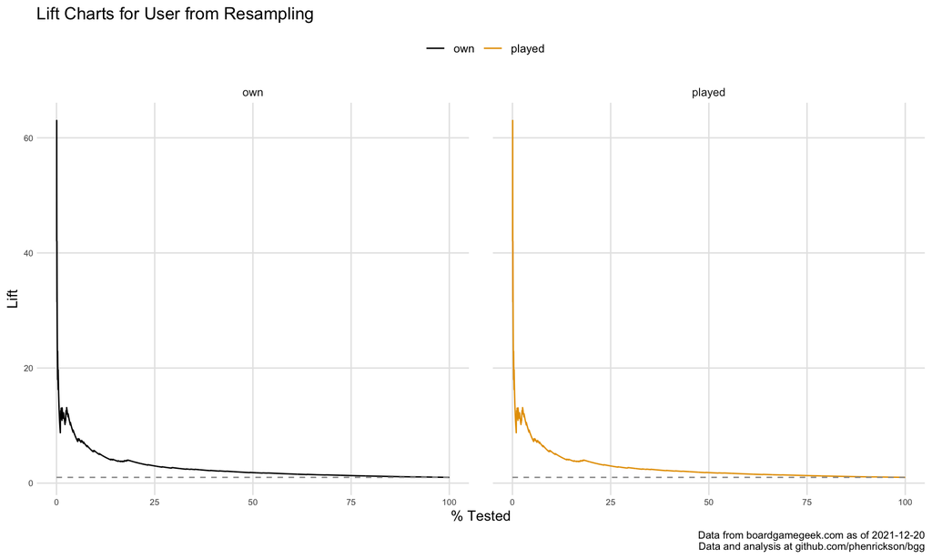

## 3.3 Most and Least Likely Games

What games does the model think GOBbluth89 is **most likely to own** that are **not** in their collection?

| username | yearpublished | game_id | name | pred_own | actual_own |
| --- | --- | --- | --- | --- | --- |
| GOBbluth89 | 2018 | 205896 | Rising Sun | 0.83 | 0 |
| GOBbluth89 | 2008 | 37111 | Battlestar Galactica: The Board Game | 0.81 | 0 |
| GOBbluth89 | 2010 | 25292 | Merchants & Marauders | 0.44 | 0 |
| GOBbluth89 | 2018 | 244711 | Newton | 0.42 | 0 |
| GOBbluth89 | 2000 | 478 | Citadels | 0.38 | 0 |

What games does the model think GOBbluth89 is **least likely to own** that **are** in their collection?

| username | yearpublished | game_id | name | pred_own | actual_own |
| --- | --- | --- | --- | --- | --- |
| GOBbluth89 | 2019 | 268864 | Undaunted: Normandy | 0 | 1 |
| GOBbluth89 | 2018 | 247367 | Air, Land & Sea | 0 | 1 |
| GOBbluth89 | 2012 | 123260 | Suburbia | 0 | 1 |
| GOBbluth89 | 2018 | 244228 | Reef | 0 | 1 |
| GOBbluth89 | 2018 | 244521 | The Quacks of Quedlinburg | 0 | 1 |

## 3.4 Top Games by Year

Top 25 games most likely to be owned by the user in each year, highlighting in blue the games that the user has owned/played.

| rank | 2011 | 2012 | 2013 | 2014 | 2015 | 2016 | 2017 | 2018 | 2019 |
| --- | --- | --- | --- | --- | --- | --- | --- | --- | --- |
| 1 | Letters from Whitechapel | Wiz-War (Eighth Edition) | Impulse | Deception: Murder in Hong Kong | Blood Rage | Codenames: Pictures | Twilight Imperium: Fourth Edition | Rising Sun | Paranormal Detectives |
| 2 | Dungeon Fighter | The Last Banquet | Room 25 | Sons of Anarchy: Men of Mayhem | Mysterium | Agricola (Revised Edition) | Gloomhaven | Newton | The Lord of the Rings: Journeys in Middle-Earth |
| 3 | Takenoko | Space Cadets | Lewis & Clark: The Expedition | Sheriff of Nottingham | Runebound (Third Edition) | Terraforming Mars | Fallout | Decrypto | The Magnificent |
| 4 | Mage Knight Board Game | Merchant of Venus (Second Edition) | Patchistory | Camel Up | 504 | Black Orchestra | Gaia Project | The Grizzled: Armistice Edition | Era: Medieval Age |
| 5 | A Game of Thrones: The Board Game (Second Edition) | Descent: Journeys in the Dark (Second Edition) | Warhammer: Diskwars | Spyfall | Forbidden Stars | Mansions of Madness: Second Edition | Breaking Bad: The Board Game | Arkham Horror (Third Edition) | Last Bastion |
| 6 | Tragedy Looper | Dixit: Journey | Sail to India | Akrotiri | Grand Austria Hotel | When I Dream | Pandemic Legacy: Season 2 | Cosmic Encounter: 42nd Anniversary Edition | Maracaibo |
| 7 | Gears of War: The Board Game | Keyflower | Bomb Squad | DungeonQuest Revised Edition | Salem 1692 | Pandemic: Reign of Cthulhu | Fog of Love | Shadows: Amsterdam | Yukon Airways |
| 8 | Eclipse | Zombicide | Smash Up: Awesome Level 9000 | Nations: The Dice Game | The King Is Dead | Dead of Winter: The Long Night | Pulsar 2849 | The World of SMOG: Rise of Moloch | Century: A New World |
| 9 | Panic Station | Archipelago | Tash-Kalar: Arena of Legends | Spurs: A Tale in the Old West | The Voyages of Marco Polo | Game of Thrones: The Iron Throne | This War of Mine: The Board Game | Coimbra | Sierra West |
| 10 | Mansions of Madness | War of the Ring: Second Edition | Eldritch Horror | Arcadia Quest | Codenames | Inis | Codenames: Duet | Root | Clank!: Legacy – Acquisitions Incorporated |
| 11 | A Few Acres of Snow | Clash of Cultures | Blood Bound | Witness | Fury of Dracula (Third/Fourth Edition) | Beyond Baker Street | Magic Maze | Muse: Awakenings | The Isle of Cats |
| 12 | Ventura | Smash Up | BattleLore: Second Edition | HINT | The Grizzled | Smash Up: Cease and Desist | The Godfather: Corleone's Empire | Heroes of Terrinoth | Tainted Grail: The Fall of Avalon |
| 13 | Pastiche | Android: Infiltration | Theseus: The Dark Orbit | Istanbul | Chaosmos | Star Wars: Rebellion | Smash Up: What Were We Thinking? | Brass: Birmingham | KeyForge: Age of Ascension |
| 14 | Alcatraz: The Scapegoat | Dixit Jinx | Berserk: War of the Realms | Star Wars: Imperial Assault | Bastion | Islebound | Massive Darkness | DC Spyfall | Star Wars: Outer Rim |
| 15 | Mundus Novus | Serenissima (Second Edition) | Prosperity | Heroes of Normandie | The Pursuit of Happiness | Captain Sonar | Whitehall Mystery | Railroad Ink: Blazing Red Edition | Black Angel |
| 16 | The Adventurers: The Pyramid of Horus | Winter Tales | Train Heist | Five Tribes | Unusual Suspects | Citadels | Clans of Caledonia | Century: Eastern Wonders | Amul |
| 17 | Flash Point: Fire Rescue | Rex: Final Days of an Empire | Firefly: The Game | La Granja | Watson & Holmes | Codenames: Deep Undercover | Summit: The Board Game | Treasure Island | Zombicide: Invader |
| 18 | Sekigahara: The Unification of Japan | Terra Mystica | Gearworld: The Borderlands | Praetor | Aye, Dark Overlord! The Green Box | New Angeles | A Game of Thrones: Catan – Brotherhood of the Watch | A Song of Ice & Fire: Tabletop Miniatures Game – Stark vs Lannister Starter Set | Tiny Towns |
| 19 | Discworld: Ankh-Morpork | Targi | Mascarade | Dead of Winter: A Crossroads Game | Mission: Red Planet (Second Edition) | The Oregon Trail Card Game | Harvest Dice | Kero | Pax Pamir: Second Edition |
| 20 | Rune Age | Spartacus: A Game of Blood and Treachery | BANG! The Dice Game | Star Wars: Empire vs. Rebellion | Drakon (Fourth Edition) | Kreus | Muse | Gen7: A Crossroads Game | Aquatica |
| 21 | Eminent Domain | Kairo | Ultimate Werewolf: Inquisition | Smash Up: Science Fiction Double Feature | FUSE | DOOM: The Board Game | Richard the Lionheart | Everdell | Barrage |
| 22 | Blood Bowl: Team Manager – The Card Game | Robinson Crusoe: Adventures on the Cursed Island | LEADERS: The Combined Strategy Game | Smash Up: Monster Smash | ...and then, we held hands. | Smash Up: It's Your Fault! | Downforce | Zombicide: Green Horde | Ticket to Ride: London |
| 23 | Elder Sign | VivaJava: The Coffee Game | Euphoria: Build a Better Dystopia | Patchwork | Coffee Roaster | 13 Days: The Cuban Missile Crisis | Santo Domingo | Renegade | GROWL |
| 24 | Dixit: Odyssey | Sky Traders | Zombicide Season 2: Prison Outbreak | Imperial Settlers | Haspelknecht | The Oracle of Delphi | LYNGK | Pandemic: Fall of Rome | Pharaon |
| 25 | Rory's Story Cubes: Voyages | Sewer Pirats | Crossing | Castles of Mad King Ludwig | Burgle Bros. | Sherlock Holmes Consulting Detective: Jack the Ripper & West End Adventures | Valletta | Narcos: The Board Game | The King's Dilemma |

## 3.5 Interactive Predictions from Resampling

Interactive table for predictions from resampling.

|  | username | yearpublished | rank | game_id | name | pred_played | pred_own | actual_played | actual_own |
| --- | --- | --- | --- | --- | --- | --- | --- | --- | --- |
| 1 | GOBbluth89 | 1900 | 547 | 15878 | Rummy | 0.02 | 0.02 | 0 | 0 |
| 2 | GOBbluth89 | 1900 | 567 | 45 | Perudo | 0.02 | 0.02 | 0 | 0 |
| 3 | GOBbluth89 | 1900 | 760 | 1602 | The Royal Game of Ur | 0.01 | 0.01 | 0 | 0 |
| 4 | GOBbluth89 | 1900 | 762 | 2397 | Backgammon | 0.01 | 0.01 | 0 | 0 |
| 5 | GOBbluth89 | 1900 | 845 | 10213 | Fox and Geese | 0.01 | 0.01 | 0 | 0 |
| 6 | GOBbluth89 | 1900 | 1353 | 38950 | Halma | 0.01 | 0.01 | 0 | 0 |
| 7 | GOBbluth89 | 1900 | 1951 | 2386 | Chinese Checkers | 0.01 | 0.01 | 0 | 0 |
| 8 | GOBbluth89 | 1900 | 1956 | 5432 | Chutes and Ladders | 0.01 | 0.01 | 0 | 0 |
| 9 | GOBbluth89 | 1900 | 2029 | 2785 | Game of Goose | 0.01 | 0.01 | 0 | 0 |
| 10 | GOBbluth89 | 1900 | 2051 | 11670 | The Game of Authors | 0.01 | 0.01 | 0 | 0 |

[output cut: 7426 more lines]

# 4 Validating the Model on 2020

How well did a model trained on a user’s collection through 2019 perform in predicting games for the user from 2020?

| username | outcome_type | yearpublished | .metric | .estimator | .estimate |
| --- | --- | --- | --- | --- | --- |
| GOBbluth89 | own | 2020 | roc_auc | binary | 0.818 |
| GOBbluth89 | played | 2020 | roc_auc | binary | 0.818 |

Table of top 25 games from 2020, highlighting games that the user owns.

| username | yearpublished | game_id | name | pred_own | pred_played | actual_own | actual_played |
| --- | --- | --- | --- | --- | --- | --- | --- |
| GOBbluth89 | 2020 | 291457 | Gloomhaven: Jaws of the Lion | 0.35 | 0.35 | 1 | 1 |
| GOBbluth89 | 2020 | 298572 | Cosmic Encounter Duel | 0.20 | 0.20 | 0 | 0 |
| GOBbluth89 | 2020 | 292333 | Cowboys II: Cowboys & Indians Edition | 0.14 | 0.14 | 0 | 0 |
| GOBbluth89 | 2020 | 184267 | On Mars | 0.12 | 0.12 | 0 | 0 |
| GOBbluth89 | 2020 | 306481 | Tawantinsuyu: The Inca Empire | 0.08 | 0.08 | 0 | 0 |
| GOBbluth89 | 2020 | 246900 | Eclipse: Second Dawn for the Galaxy | 0.06 | 0.06 | 0 | 0 |
| GOBbluth89 | 2020 | 256317 | Guild Master | 0.06 | 0.06 | 0 | 0 |
| GOBbluth89 | 2020 | 301767 | Mysterium Park | 0.06 | 0.06 | 0 | 0 |
| GOBbluth89 | 2020 | 314040 | Pandemic Legacy: Season 0 | 0.06 | 0.06 | 0 | 0 |
| GOBbluth89 | 2020 | 319966 | The King Is Dead: Second Edition | 0.06 | 0.06 | 0 | 0 |
| GOBbluth89 | 2020 | 282922 | Windward | 0.05 | 0.05 | 0 | 0 |
| GOBbluth89 | 2020 | 299179 | Chancellorsville 1863 | 0.05 | 0.05 | 0 | 0 |
| GOBbluth89 | 2020 | 306735 | Under Falling Skies | 0.05 | 0.05 | 1 | 1 |
| GOBbluth89 | 2020 | 308652 | Age of Dogfights: WW1 | 0.05 | 0.05 | 0 | 0 |
| GOBbluth89 | 2020 | 293889 | Fallout Shelter: The Board Game | 0.04 | 0.04 | 0 | 0 |
| GOBbluth89 | 2020 | 295905 | Cosmic Frog | 0.04 | 0.04 | 0 | 0 |
| GOBbluth89 | 2020 | 297030 | Tekhenu: Obelisk of the Sun | 0.04 | 0.04 | 0 | 0 |
| GOBbluth89 | 2020 | 245658 | Unicorn Fever | 0.03 | 0.03 | 0 | 0 |
| GOBbluth89 | 2020 | 256940 | Krosmaster: Blast | 0.03 | 0.03 | 0 | 0 |
| GOBbluth89 | 2020 | 282081 | The Zorro Dice Game | 0.03 | 0.03 | 0 | 0 |
| GOBbluth89 | 2020 | 296892 | Sacred Rites | 0.03 | 0.03 | 0 | 0 |
| GOBbluth89 | 2020 | 300322 | Hallertau | 0.03 | 0.03 | 0 | 0 |
| GOBbluth89 | 2020 | 301716 | Glasgow | 0.03 | 0.03 | 0 | 0 |
| GOBbluth89 | 2020 | 301919 | Pandemic: Hot Zone – North America | 0.03 | 0.03 | 0 | 0 |
| GOBbluth89 | 2020 | 302465 | Obsidia | 0.03 | 0.03 | 0 | 0 |

# 5 Predicting Upcoming Games (2020 and On) for **GOBbluth89**

Examine the top games for the test set.

| username | yearpublished | game_id | name | rank | own | played |
| --- | --- | --- | --- | --- | --- | --- |
| GOBbluth89 | 2020 | 291457 | Gloomhaven: Jaws of the Lion | 1 | 0.35 | 0.35 |
| GOBbluth89 | 2020 | 298572 | Cosmic Encounter Duel | 2 | 0.20 | 0.20 |
| GOBbluth89 | 2020 | 292333 | Cowboys II: Cowboys & Indians Edition | 3 | 0.14 | 0.14 |
| GOBbluth89 | 2020 | 184267 | On Mars | 4 | 0.12 | 0.12 |
| GOBbluth89 | 2020 | 306481 | Tawantinsuyu: The Inca Empire | 5 | 0.08 | 0.08 |
| GOBbluth89 | 2020 | 314040 | Pandemic Legacy: Season 0 | 6 | 0.06 | 0.06 |
| GOBbluth89 | 2020 | 246900 | Eclipse: Second Dawn for the Galaxy | 7 | 0.06 | 0.06 |
| GOBbluth89 | 2020 | 319966 | The King Is Dead: Second Edition | 8 | 0.06 | 0.06 |
| GOBbluth89 | 2020 | 301767 | Mysterium Park | 9 | 0.06 | 0.06 |
| GOBbluth89 | 2020 | 256317 | Guild Master | 10 | 0.06 | 0.06 |
| GOBbluth89 | 2020 | 299179 | Chancellorsville 1863 | 11 | 0.05 | 0.05 |
| GOBbluth89 | 2020 | 308652 | Age of Dogfights: WW1 | 12 | 0.05 | 0.05 |
| GOBbluth89 | 2020 | 306735 | Under Falling Skies | 13 | 0.05 | 0.05 |
| GOBbluth89 | 2020 | 282922 | Windward | 14 | 0.05 | 0.05 |
| GOBbluth89 | 2020 | 293889 | Fallout Shelter: The Board Game | 15 | 0.04 | 0.04 |
| GOBbluth89 | 2020 | 295905 | Cosmic Frog | 16 | 0.04 | 0.04 |
| GOBbluth89 | 2020 | 297030 | Tekhenu: Obelisk of the Sun | 17 | 0.04 | 0.04 |
| GOBbluth89 | 2020 | 296892 | Sacred Rites | 18 | 0.03 | 0.03 |
| GOBbluth89 | 2020 | 308765 | Praga Caput Regni | 19 | 0.03 | 0.03 |
| GOBbluth89 | 2020 | 282081 | The Zorro Dice Game | 20 | 0.03 | 0.03 |
| GOBbluth89 | 2020 | 316554 | Dune: Imperium | 21 | 0.03 | 0.03 |
| GOBbluth89 | 2020 | 301919 | Pandemic: Hot Zone – North America | 22 | 0.03 | 0.03 |
| GOBbluth89 | 2020 | 312965 | Hogs of War: The Miniatures Game | 23 | 0.03 | 0.03 |
| GOBbluth89 | 2020 | 323784 | Ghost Letters | 24 | 0.03 | 0.03 |
| GOBbluth89 | 2020 | 316377 | 7 Wonders (Second Edition) | 25 | 0.03 | 0.03 |
| GOBbluth89 | 2021 | 285967 | Ankh: Gods of Egypt | 1 | 0.23 | 0.23 |
| GOBbluth89 | 2021 | 298102 | Roll Camera!: The Filmmaking Board Game | 2 | 0.17 | 0.17 |
| GOBbluth89 | 2021 | 291859 | Riftforce | 3 | 0.15 | 0.15 |
| GOBbluth89 | 2021 | 340466 | Unfathomable | 4 | 0.10 | 0.10 |
| GOBbluth89 | 2021 | 310873 | Carnegie | 5 | 0.08 | 0.08 |
| GOBbluth89 | 2021 | 343905 | Boonlake | 6 | 0.08 | 0.08 |
| GOBbluth89 | 2021 | 291847 | Mantis Falls | 7 | 0.07 | 0.07 |
| GOBbluth89 | 2021 | 291572 | Oath: Chronicles of Empire and Exile | 8 | 0.06 | 0.06 |
| GOBbluth89 | 2021 | 249277 | Brazil: Imperial | 9 | 0.06 | 0.06 |
| GOBbluth89 | 2021 | 342848 | World of Warcraft: Wrath of the Lich King | 10 | 0.06 | 0.06 |
| GOBbluth89 | 2021 | 273330 | Bloodborne: The Board Game | 11 | 0.06 | 0.06 |
| GOBbluth89 | 2021 | 335541 | We Care: a Grizzled Game | 12 | 0.05 | 0.05 |
| GOBbluth89 | 2021 | 313730 | Harsh Shadows | 13 | 0.04 | 0.04 |
| GOBbluth89 | 2021 | 342942 | Ark Nova | 14 | 0.04 | 0.04 |
| GOBbluth89 | 2021 | 331685 | Hit the Silk! | 15 | 0.04 | 0.04 |
| GOBbluth89 | 2021 | 295785 | Euthia: Torment of Resurrection | 16 | 0.04 | 0.04 |
| GOBbluth89 | 2021 | 318084 | Furnace | 17 | 0.04 | 0.04 |
| GOBbluth89 | 2021 | 298383 | Golem | 18 | 0.04 | 0.04 |
| GOBbluth89 | 2021 | 322708 | Descent: Legends of the Dark | 19 | 0.04 | 0.04 |
| GOBbluth89 | 2021 | 318184 | Imperium: Classics | 20 | 0.03 | 0.03 |
| GOBbluth89 | 2021 | 324242 | Sheepy Time | 21 | 0.03 | 0.03 |
| GOBbluth89 | 2021 | 341169 | Great Western Trail (Second Edition) | 22 | 0.03 | 0.03 |
| GOBbluth89 | 2021 | 295535 | Dark Ages: Heritage of Charlemagne | 23 | 0.03 | 0.03 |
| GOBbluth89 | 2021 | 304985 | Dark Ages: Holy Roman Empire | 24 | 0.03 | 0.03 |
| GOBbluth89 | 2021 | 251661 | Oathsworn: Into the Deepwood | 25 | 0.03 | 0.03 |
| GOBbluth89 | 2022 | 331106 | The Witcher: Old World | 1 | 0.33 | 0.33 |
| GOBbluth89 | 2022 | 295770 | Frosthaven | 2 | 0.13 | 0.13 |
| GOBbluth89 | 2022 | 317511 | Tindaya | 3 | 0.10 | 0.10 |
| GOBbluth89 | 2022 | 283137 | Human Punishment: The Beginning | 4 | 0.06 | 0.06 |
| GOBbluth89 | 2022 | 256680 | Return to Dark Tower | 5 | 0.05 | 0.05 |
| GOBbluth89 | 2022 | 338067 | 6: Siege – The Board Game | 6 | 0.04 | 0.04 |
| GOBbluth89 | 2022 | 322524 | Bardsung | 7 | 0.04 | 0.04 |
| GOBbluth89 | 2022 | 299106 | Fractal: Beyond the Void | 8 | 0.04 | 0.04 |
| GOBbluth89 | 2022 | 319807 | Shogun no Katana | 9 | 0.03 | 0.03 |
| GOBbluth89 | 2022 | 334065 | Verdant | 10 | 0.03 | 0.03 |
| GOBbluth89 | 2022 | 304051 | Creature Comforts | 11 | 0.03 | 0.03 |
| GOBbluth89 | 2022 | 273814 | Deliverance | 12 | 0.03 | 0.03 |
| GOBbluth89 | 2022 | 340325 | Vagrantsong | 13 | 0.03 | 0.03 |
| GOBbluth89 | 2022 | 281647 | Stellaris: Infinite Legacy | 14 | 0.02 | 0.02 |
| GOBbluth89 | 2022 | 311823 | Nova Aetas Renaissance | 15 | 0.02 | 0.02 |
| GOBbluth89 | 2022 | 280726 | Legacies | 16 | 0.02 | 0.02 |
| GOBbluth89 | 2022 | 317321 | Darkest Dungeon: The Board Game | 17 | 0.02 | 0.02 |
| GOBbluth89 | 2022 | 271601 | Feed the Kraken | 18 | 0.02 | 0.02 |
| GOBbluth89 | 2022 | 312959 | Rallyman: DIRT | 19 | 0.02 | 0.02 |
| GOBbluth89 | 2022 | 254632 | Hyperspace | 20 | 0.01 | 0.01 |
| GOBbluth89 | 2022 | 275284 | Arkeis | 21 | 0.01 | 0.01 |
| GOBbluth89 | 2022 | 315695 | Veiled Fate | 22 | 0.01 | 0.01 |
| GOBbluth89 | 2022 | 286063 | The 7th Citadel | 23 | 0.01 | 0.01 |
| GOBbluth89 | 2022 | 295895 | Distilled | 24 | 0.01 | 0.01 |
| GOBbluth89 | 2022 | 313065 | Transmissions | 25 | 0.01 | 0.01 |

## 5.1 Interactive Table for Upcoming Games 2020 and On

|  | username | yearpublished | game_id | name | rank | own | played |
| --- | --- | --- | --- | --- | --- | --- | --- |
| 1 | GOBbluth89 | 2020 | 291457 | Gloomhaven: Jaws of the Lion | 1 | 0.35 | 0.35 |
| 2 | GOBbluth89 | 2022 | 331106 | The Witcher: Old World | 2 | 0.33 | 0.33 |
| 3 | GOBbluth89 | 2021 | 285967 | Ankh: Gods of Egypt | 3 | 0.23 | 0.23 |
| 4 | GOBbluth89 | 2020 | 298572 | Cosmic Encounter Duel | 4 | 0.2 | 0.2 |
| 5 | GOBbluth89 | 2021 | 298102 | Roll Camera!: The Filmmaking Board Game | 5 | 0.17 | 0.17 |
| 6 | GOBbluth89 | 2021 | 291859 | Riftforce | 6 | 0.15 | 0.15 |
| 7 | GOBbluth89 | 2020 | 292333 | Cowboys II: Cowboys &amp; Indians Edition | 7 | 0.14 | 0.14 |
| 8 | GOBbluth89 | 2022 | 295770 | Frosthaven | 8 | 0.13 | 0.13 |
| 9 | GOBbluth89 | 2020 | 184267 | On Mars | 9 | 0.12 | 0.12 |
| 10 | GOBbluth89 | 2021 | 340466 | Unfathomable | 10 | 0.1 | 0.1 |

[output cut: 1627 more lines]